# Clase 6: Desarrollo de aplicación para un gimnasio

## Resumen parcial de códigos

- `ventana = tk.Tk()`: creas tu ventana
- `ventana.geometry()`: configuración del tamaño de la ventana
- `ventana.title()`: configurar un título a la ventana
- `ttk`: es parte de la librería de tkinter que nos permite colocar herramientas dentro de nuestra ventana.
- `ttk.Label()`: colocar etiquetas en nuestra venta --> `.grid(x, y)`: nos permite colocar en el lugar coordenada la ubicación de la etiqueta de texto.
- `ttk.Entry()`: nos permite colocar cajas de texto.
- `ventana.mainloop()`: ejecuta en bucle nuestra aplicación o interfaz.

# Código clase pasada

```python
# mensajes emergente:
# error
# askyesorno
# info
from tkinter import messagebox

# Instanciar/inicializacion nuestra ventana
login = tk.Tk()

# configurar un tamaño
#             largo x Ancho
login.geometry('400x200')

# configurar un titulo
login.title('Login 🥸')

# seccion de espacios en blanco para un espacio de identacion
etiqueta_espacio_blanco_1 = ttk.Label(login, text='                      ')
etiqueta_espacio_blanco_1.grid(row=1, column=0)

# Saltos de linea
etiqueta_espacio_blanco_2 = ttk.Label(login, text='                      ')
etiqueta_espacio_blanco_2.grid(row=2, column=1)

etiqueta_espacio_blanco_3 = ttk.Label(login, text='                      ')
etiqueta_espacio_blanco_3.grid(row=3, column=1)

# agregar un texto ttk.Label(ventana, texto)
etiqueta_titulo_login = ttk.Label(login,
                                  text='Mi primera aplicación web',
                                  font=('Arial', 16))

# localizacion de nuestra etiqueta
etiqueta_titulo_login.grid(row=1, column=1, sticky='NSWE')

etiqueta_password = ttk.Label(login, text='Password', font=('Arial', 12))
etiqueta_password.grid(row=4, column=0, sticky='NSWE')

# Procedemos a colocar una caja de texto
caja_etiqueta_password = ttk.Entry(login, show='*')
# padx: margen horizontal (para no tener todo pegado)
caja_etiqueta_password.grid(row=4, column=1, sticky='WE', padx='10')


##########################################################################
##########################################################################
# los botones van asociados con comandos: funcion
# Definicion de un boton: ttk.Button(ventana, texto, comando)
def ingresar():
    """ Comando asociado a boton_entrar_login.
    * Nos conectaremos a la bbdd para traernos los passwords
    registrados.
    """
    # Parte 1: traernos la lista con los passwords
    con = sql.connect("Gym_pym.db")
    df = pd.read_sql_query("SELECT * FROM Administradores", con)
    con.close()
    passwords_lista = list(df['passwords'])
    # Parte 2: traernos ese password de la caja caja_etiqueta_password
    # dada una caja de texto, puedes extraer la informacion de ahi
    # con el metodo get()
    password_user = caja_etiqueta_password.get()
    # Parte 3: validar que el password sea correcto
    if password_user in passwords_lista:
        # en caso de que el password este en la lista permita
        # daremos acceso
        # ------------------booleano--------------------
        # yes ---> True
        # no  ---> False
        acceso = messagebox.askyesno(message='¿Deseas continuar?')

        if acceso:
            # si el administrador le da que si, entonces abriremos la
            # app del gym (continuacion)
            login.destroy()
        else:
            # si le da en No el admin, entonces cerraremos la aplicacion
            login.destroy()
    else:
        # caso contrario, no daremos acceso
        messagebox.showerror('Contraseña incorrecta, intente de nuevo')


boton_entrar_login = ttk.Button(login, text='Ingresar', command=ingresar)
boton_entrar_login.grid(row=5, column=1)

boton_entrar_limpiar = ttk.Button(login, text='Limpiar',
                                  command=lambda: caja_etiqueta_password.delete(0, tk.END))
boton_entrar_limpiar.grid(row=6, column=1)

# Ejecutamos en bucle la interfaz
login.mainloop()
```

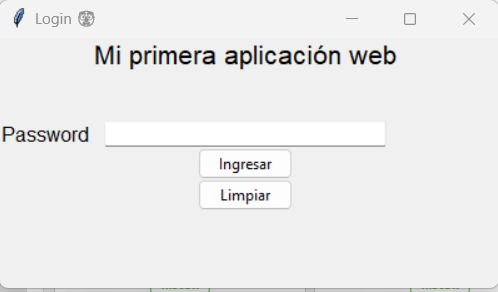